# NYC Flights Analysis

## Analysing NYC Flights Data

### Loading the dplyr package

```r
library(dplyr)
```

### Loading the flights data frame

```r
library(nycflights13)
df <- flights
```

### Getting the size of the data frame

```r
dim(df)
```

```
[1] 336776     19
```

### Questions

- How many flights originated from each of the origin airports?
- Make a variable to indicate whether a flight was cancelled: if departure delay and arrival delay are both missing.
- What were the 10 most common destination airports?
- What are the 5 airlines with most flights?
- Which airlines/airports were most likely to have departure delays greater than 15 minutes?

### Number of flights originating at each airport

```r
table(df$origin)
```

```
   EWR    JFK    LGA
120835 111279 104662
```

### Creating cancelled variable

To do this we have to use the `is.na` function.

```r
df$can <- ifelse(is.na(df$arr_delay) &
                   is.na(df$dep_delay), "Cancelled", "Not Cancelled")
table(df$can)
```

```
    Cancelled Not Cancelled
         8255        328521
```

### Most common destinations

Steps:

- use table to get counts
- sort the counts
- take the top 10
- take the names of the table

```r
names(sort(table(df$dest), decreasing = TRUE)[1:10])
```

```
 [1] "ORD" "ATL" "LAX" "BOS" "MCO" "CLT" "SFO"
 [8] "FLL" "MIA" "DCA"
```

```r
sort(table(df$carrier), decreasing = TRUE)
```

```
   UA    B6    EV    DL    AA    MQ    US
58665 54635 54173 48110 32729 26397 20536
   9E    WN    VX    FL    AS    F9    YV
18460 12275  5162  3260   714   685   601
   HA    OO
  342    32
```

#### Two different ways to add a delay variable

```r
df$del15 <- ifelse(df$dep_delay > 15, "Delayed",
                   "Not Delayed")
df <- mutate(df, del15alt = ifelse(dep_delay > 15, "Delayed", "Not Delayed"))
```

#### Contingency table of Origin airports and whether or not the flight was delayed (by more than 15 minutes)

```r
table(df$del15, df$origin)
```

```
                EWR   JFK   LGA
  Delayed     28942 22650 19182
  Not Delayed 88654 86766 82327
```

## More questions:

- What day of the year had the most flights scheduled?
- What day of the year had the least flights scheduled?

#### Getting the day with the most flights scheduled

Steps:

- group by month and day
- use `summarise` to get the counts for each day
- sort in descending order

```r
flight_counts <- group_by(df, month, day) %>%
  summarise(Scheduled = n()) %>%
  arrange(desc(Scheduled))
```

[output not shown]

#### Getting the day with the least flights scheduled

Steps:

- group by month and day
- use `summarise` to get the counts for each day
- sort in (ascending: default) order

```r
flight_counts2 <- group_by(df, month, day) %>%
  summarise(Scheduled = n()) %>%
  arrange(Scheduled)
```

[output not shown]

#### Making a plot of number of flights by day

Steps:

- first create a date variable from the year, month and day
- group the data frame by the date, then take the count for each day
- plot the counts for each day for the year

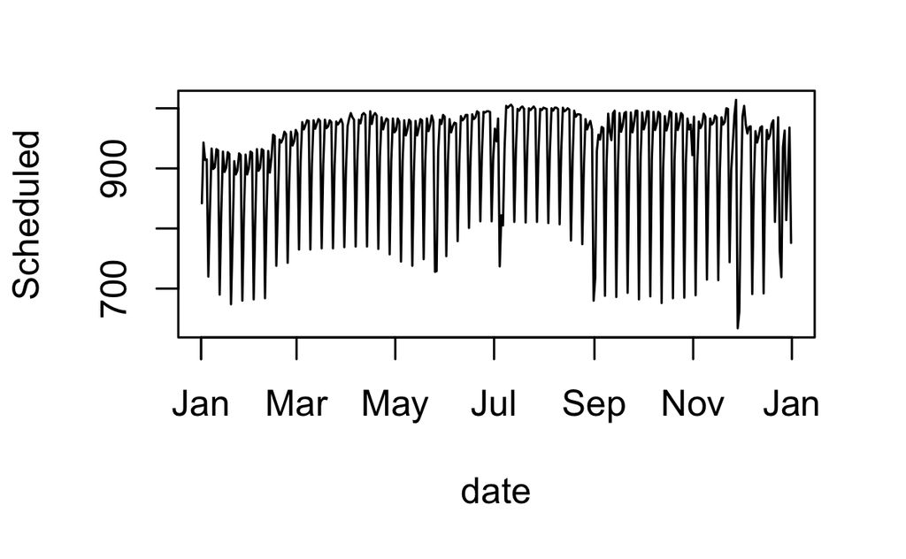

```r
daily_flights <- mutate(df, date = ISOdate(year, month, day)) %>% group_by(date) %>% summarise(Scheduled = n())

plot(Scheduled~date, data = daily_flights,
     type = "l")
```